# State Political Affiliation and Hate Crime

University of Pennsylvania

Andrew Santillan, Isabella Werneck, Kaiyla Jolley, and Niko Amber

December 12th, 2021

## *1. Introduction*

### *1.1 Research Question and Hypothesis*

Our research question is the following: Is there a relationship between a state’s political affiliation in the 2020 Presidential election and hate crime data as reported to the FBI? Following the assumption that individuals who voted for Trump are more likely to commit a hate crime, we expect to find that states that mostly voted Republican in 2020 had higher hate crime rates in 2019

## *2 Exploratory Data Analysis*

### *2.1 Data Description*

The dataset in this report contains data from the FBI 2019 Hate Crime Statistics (FBI, 2019) and from the Official 2020 Presidential General Election Results (FEC, 2021). The hate crime data was collected through the Uniform Crime Reporting (UCR) Program and it includes both single-bias and multiple-bias hate crimes. The synthesized dataset contains 50 observations and 14 variables. Six of the variables correspond to the hate crime categories, which include the following biases: race, religion, sexual orientation, disability, gender, and gender identity.

### *2.2 Missing Values*

Only 49 American states were included in the observations. Alabama did not report to the UCR Program, and so it was excluded from the dataset. Washington D.C. reported to the UCR as a separate entity, and so it was included as a separate observation. It is important to note that participation in the Federal UCR Program Initiative is voluntary, which means that state jurisdictions can choose not to report. In the case of Alabama, the entire state chose not to participate in the UCR Program, but for all other states there are jurisdictions missing from the dataset. Therefore, there is a distinction between total state population and population covered. The term “population covered” means the total population covered by the jurisdictions that chose to report. For example, the total population of Florida is 21.5 million, and the population covered is approximately 20.9 million. Due to the voluntary nature of the UCR Program, there are many missing values in the dataset.

### *2.3 Percentage of population that reported to the FBI*

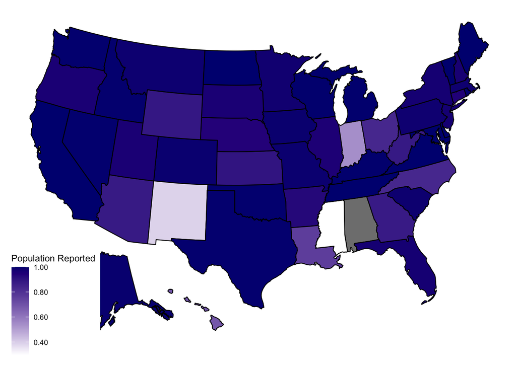

```r
dat <- read.csv(file = "/Users/nikoamber/Library/Mobile Documents/com~apple~CloudDocs/Penn/Freshman Fall/Criminology/Final Data - Final Project Data with Rates.csv")
library(tidyverse)
library(usmap)

plot_usmap(data = dat, values = "pop_rat") +
   scale_fill_continuous( low = "white", high = "navy",
                         name = "Population Reported", label = scales::comma
  )
```

### *2.4 Total hate crime per state*

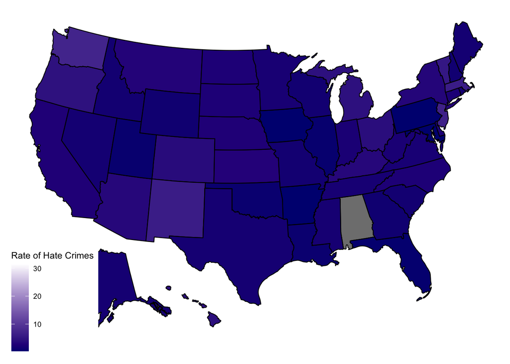

```r
plot_usmap(data = dat, values = "rate") +
   scale_fill_continuous( low = "navy", high = "white",
                         name = "Rate of Hate Crimes", label = scales::comma
  )
```

### *2.5 Codebook*

pop_cov: Population covered by FBI pop_tot: Total state population pop_rat: Population covered by FBI/total state population perc_rep: Percentage of population that voted for Trump perc_dem: Percentage of population that voted for Biden rep_dem: Republican (R) rate: Number of hate crimes reported per 100,000 Rate_rea: number of racially motivated hate crime per 100,000 Rate_rel: number of hate crimes against religion per 100,000 Rate_sex: number of hate crimes against sexual orientation per 100,000 Rate_dis: number of hate crimes against disabilities per 100,000 Rate_gen: number of hate crimes against gender per 100,000 Rate_gei: number of hate crimes against gender identity per 100,000

## *2.6 Scatterplots*

*Note: We have labelled significant outlines to facilitate visial analysis.*

*Please see codebook for variable names*

**Percentage that Voted Republican vs. Rate of Total Hate Crime**

```r
# rate Hate Crimes vs. Political Affiliation
scatter.smooth(
  x=dat$perc_rep,
  xlab="Percentage Republican",
  y=dat$rate,
  ylab="rate Hate Crimes Reported (per 100,000)",
  main="rate Hate Crimes vs. Political Affiliation"
)

text(
  x=c(5.40),
  y=c(31.464),
  labels=c("D.C."),
  pos=1
)
```

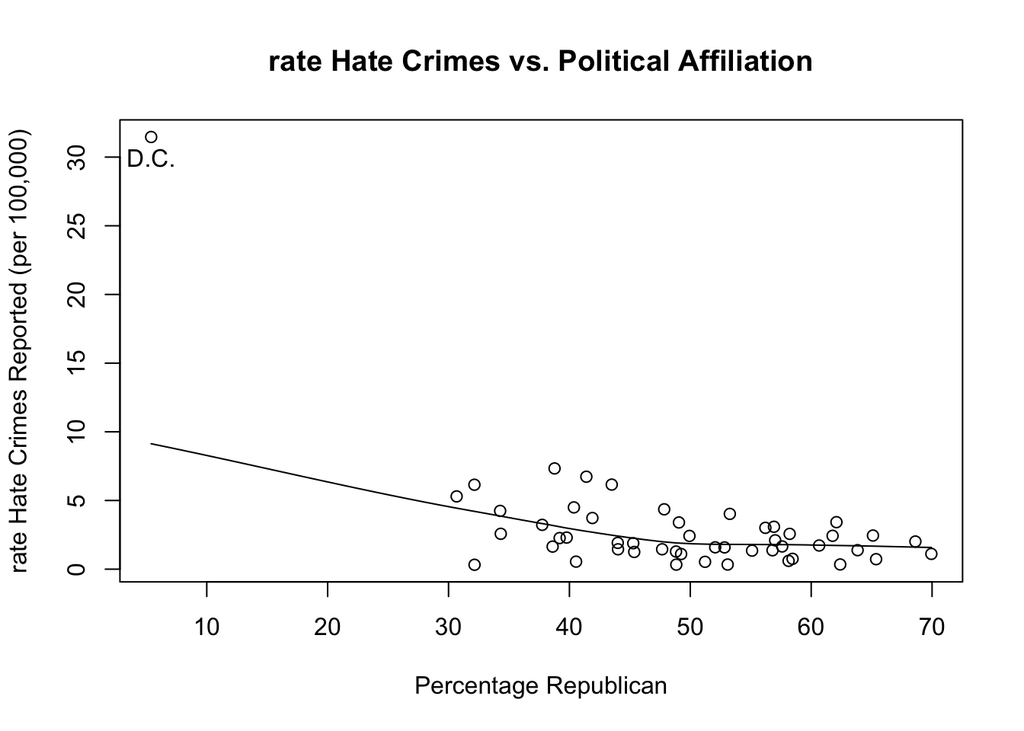

**Percentage that Voted Republican vs. Rate of Race/Ethnicity Hate Crime**

```r
# rate_rea Hate Crimes vs. Political Affiliation
scatter.smooth(
  x=dat$perc_rep,
  xlab="Percentage Republican",
  y=dat$rate_rea,
  ylab="rate_rea Hate Crimes Reported (per 100,000)",
  main="rate_rea Hate Crimes vs. Political Affiliation"
)

text(
  x=c(5.40),
  y=c(16.86),
  labels=c("D.C."),
  pos=1
)
```

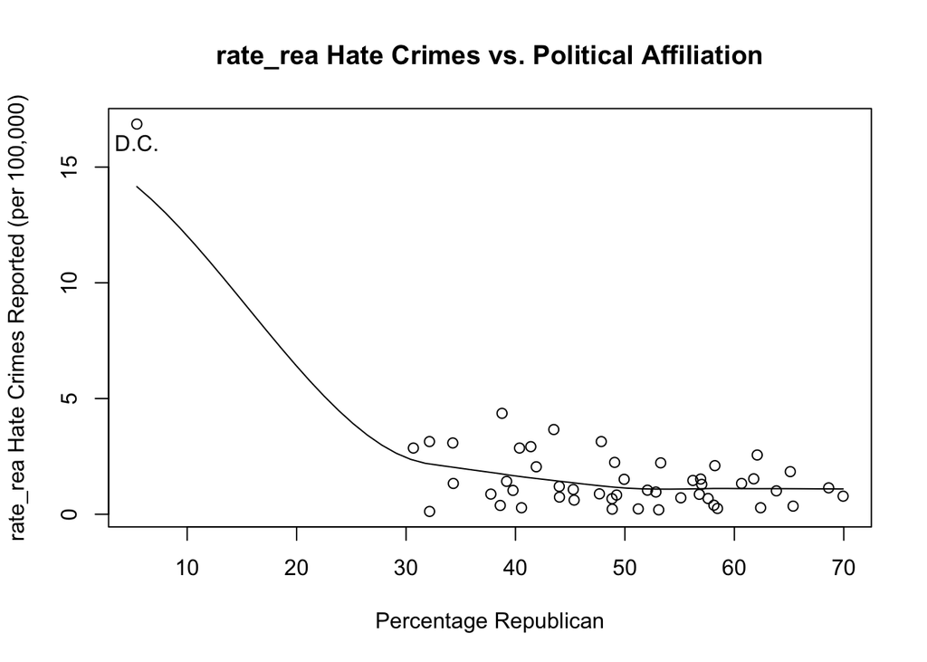

**Percentage that Voted Republican vs. Rate of Religion Hate Crime**

```r
# rate_rel Hate Crimes vs. Political Affiliation
scatter.smooth(
  x=dat$perc_rep,
  xlab="Percentage Republican",
  y=dat$rate_rel,
  ylab="rate_rel Hate Crimes Reported (per 100,000)",
  main="rate_rel Hate Crimes vs. Political Affiliation"
)

text(
  x=c(5.40, 41.4, 37.75),
  y=c(1.134, 2.894, 1.884),
  labels=c("D.C", "New Jersey", "New York"),
  pos=c(3, 1, 1)
)
```

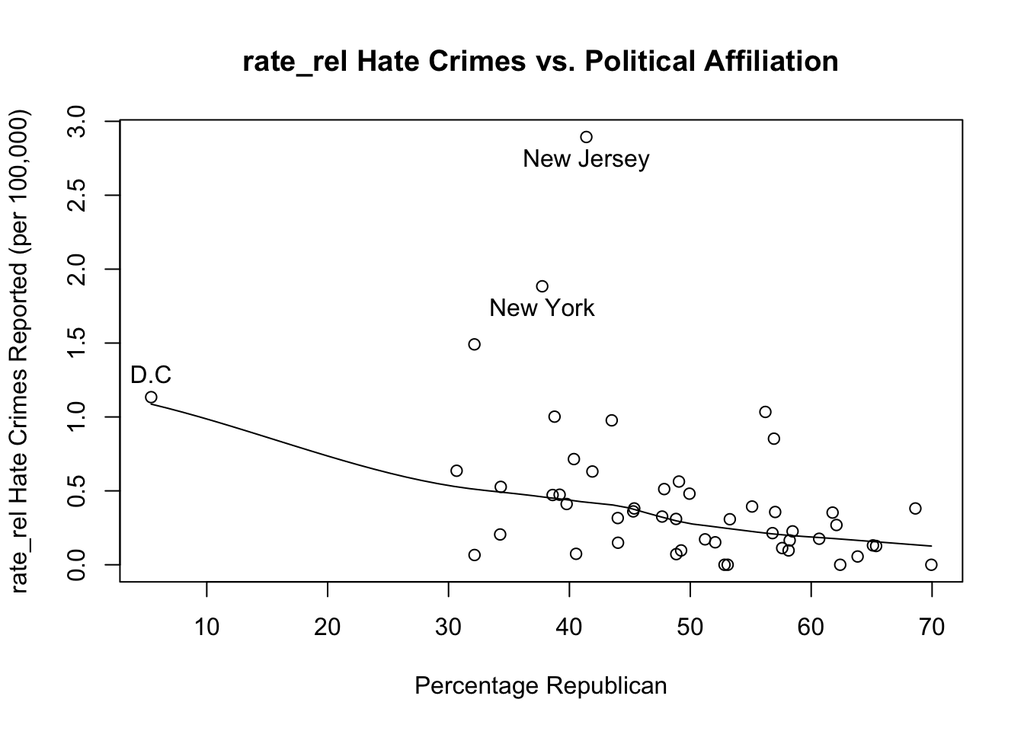

**Percentage that Voted Republican vs. Rate of Sexual Orientation Hate Crime**

```r
# rate_sex Hate Crimes vs. Political Affiliation
scatter.smooth(
  x=dat$perc_rep,
  xlab="Percentage Republican",
  y=dat$rate_sex,
  ylab="rate_sex Hate Crimes Reported (per 100,000)",
  main="rate_sex Crimes vs. Political Affiliation"
)

text(
  x=c(5.40),
  y=c(9.21),
  labels=c("D.C."),
  pos=1
)
```

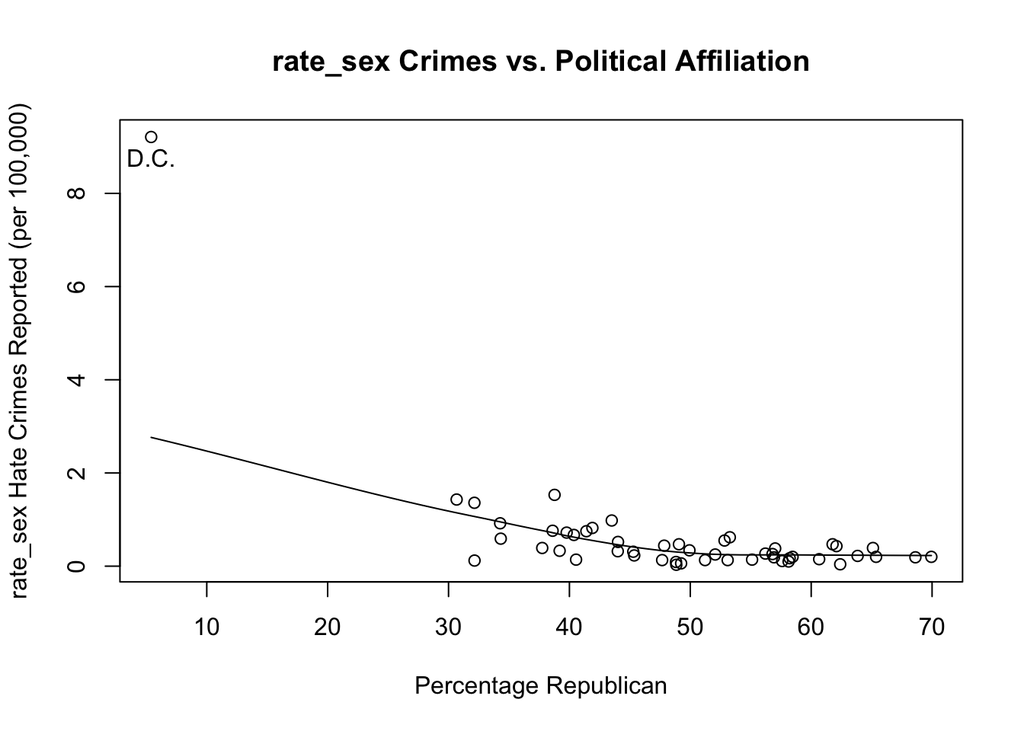

**Percentage that Voted Republican vs. Rate of Disability Hate Crime**